# Lista 4

# 2 Exercício: Curva de Potência para uma Normal Contaminada

Considere o teste de comparação de médias:

$$\begin{cases}
H_0 : \mu_1 = \mu_2 = 0 \\
H_1 : \mu_1 \ne \mu_2
\end{cases}$$

Estude o poder do teste para $\alpha = 0.05$, $n = m \in \{10, 20, 50, 100, 500\}$ e $\sigma_1 = \sigma_2 = 1$. Sob $H_1$, considere uma normal contaminada:

$$X,Y \sim (1 - \epsilon) \mathcal{N}(0, 1) + \epsilon \mathcal{N}(50, 1), \quad 0 \leq \epsilon \leq 1$$

Use 1000 réplicas de Monte Carlo. Faça o gráfico da curva de potência em função de $\epsilon$ e comente os resultados.

### 2.0.1 Solução

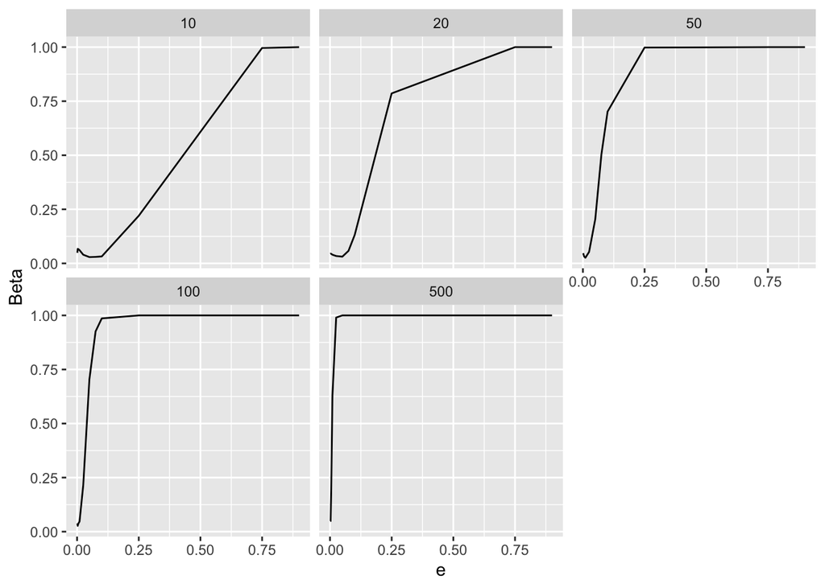

```r
library(tidyverse)

n_MC <- 1000
ns <- c(10, 20, 50, 100, 500)
es <- c(0.001, 0.0025, 0.005, 0.01, 0.025, 0.05, 0.075, 0.1, 0.25, 0.75, 0.9)

df <- data.frame(n = numeric(), e = numeric(), Beta = numeric())

for (n in ns){
  for(epsilon in es){

    a <- map_lgl(1:n_MC , ~{
      aa1 <- rnorm(n, 0, 1)

      N_cont <- function(n) {
        ind <- rbinom(n, 1, epsilon)
        rnorm(n, mean = ind * 50, sd = 1)
      }

      aa2 <- N_cont(n)
      t.test(aa1, aa2, var.equal = TRUE)$p.value < 0.05
    })

    df <- rbind(df, data.frame(n = n, e = epsilon, Beta = mean(a)))
  }
}

df |>
  ggplot(aes(x = e, y = Beta)) +
  geom_line() +
  facet_wrap(~n)
```

Nesse cenário, a hipótese nula é de fato falsa (sempre há alguma porcentagem de contaminação) e estamos medindo é a potência do teste, ou seja, com que frequência ele acerta ao rejeitar $H_0$.

O gráfico mostra que, quanto maior o valor de $\epsilon$, mais a amostra está “contaminada” com valores vindos da normal com média 50. Isso faz com que a diferença entre os grupos aumente, facilitando a rejeição de $H_0$.

Também podemos ver que amostras maiores aumentam a potência do teste — o que é esperado, já que com mais dados a chance de detectar efeitos reais aumenta.